# BIGpicture vignette

### `plot_upset_genes`: Upset plot of DEGs

Functions the same as `plot_venn_genes`.

Plot all variables at multiple FDR cutoffs.

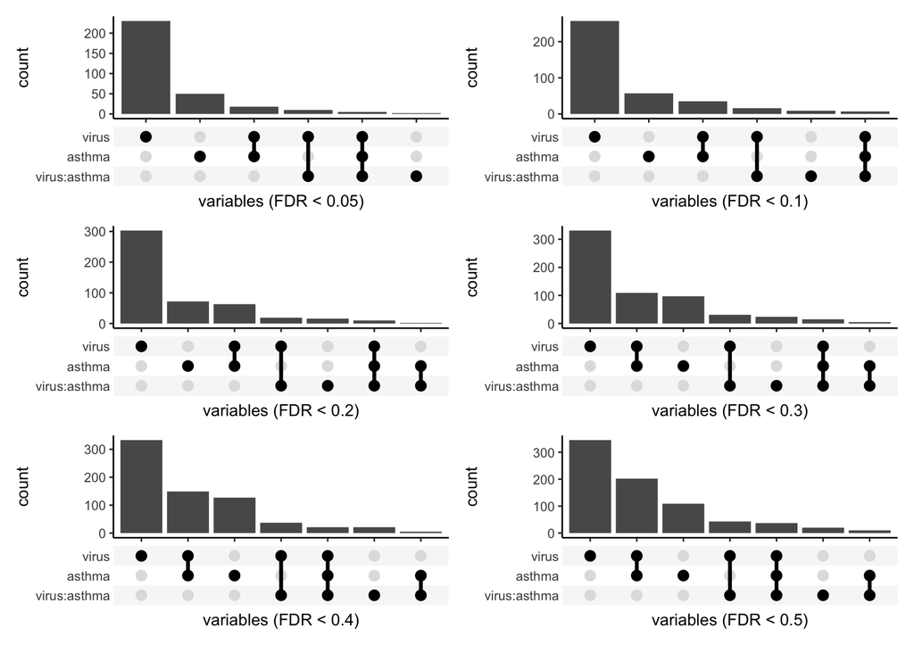

```r
plot_upset_genes(model_result = example.model,
                models = "lme")$upset %>%
  patchwork::wrap_plots(ncol=2)
```

Select specific FDR cutoff(s).

```
## $upset
## $upset$`0.05`
```

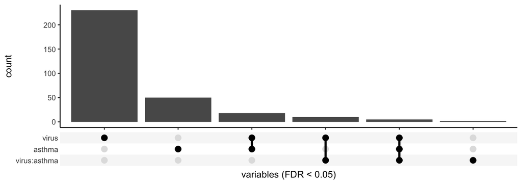

```r
plot_upset_genes(model_result = example.model,
                models = "lme",
                fdr_cutoff = 0.05)
```

Select variable(s) of interest.

```
## $upset
## $upset$`0.05`
```

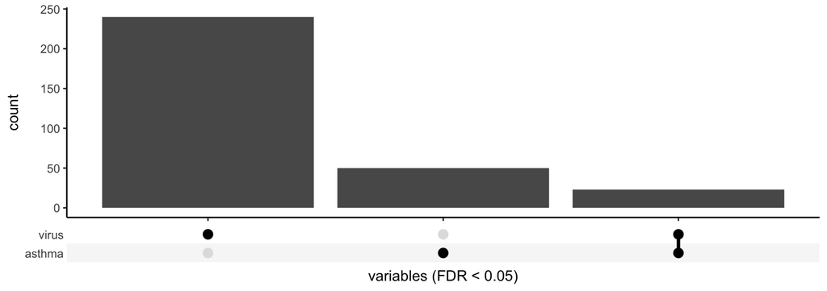

```r
plot_upset_genes(model_result = example.model,
                models = "lme",
                fdr_cutoff = 0.05,
                variables = c("asthma","virus"))
```

If you’re using a contrasts model, specify contrasts instead.

```
## $upset
## $upset$`0.5`
```

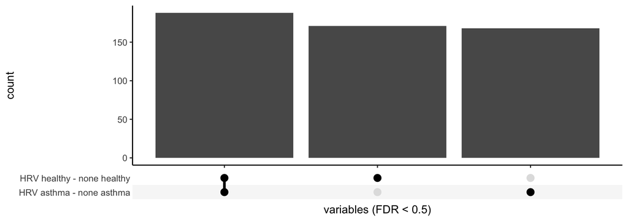

```r
plot_upset_genes(model_result = example.model,
                models = "lme.contrast",
                fdr_cutoff = 0.5,
                contrasts = c("HRV healthy - none healthy",
                              "HRV asthma - none asthma"))
```

Include the random effect and/or intercept if the model has one.

```
## $upset
## $upset$`0.05`
```

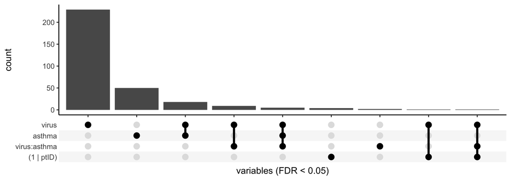

```r
plot_upset_genes(model_result = example.model,
                models = "lme",
                fdr_cutoff = 0.05,
                random = TRUE, intercept = TRUE)
```

Save the genes in each part of the Venn’s overlap for downstream analyses.

```
## $`0.05`
```

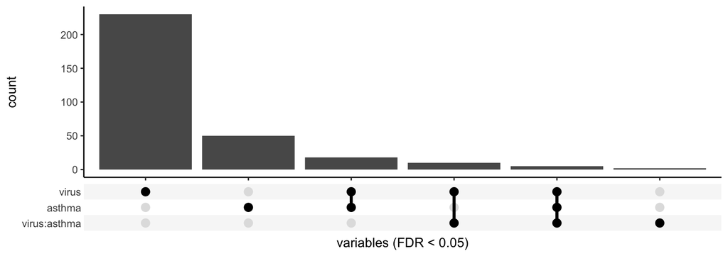

```r
upset_result <- plot_upset_genes(model_result = example.model,
                models = "lme",
                fdr_cutoff = 0.05,
                return_genes = TRUE)
upset_result$upset
```

```r
upset_result$gene$`0.05` %>% head
```

```
## # A tibble: 6 × 4
##   gene            virus asthma `virus:asthma`
##   <chr>           <chr> <chr>  <chr>
## 1 ENSG00000002587 Y     <NA>   <NA>
## 2 ENSG00000005884 <NA>  Y      <NA>
## 3 ENSG00000006712 <NA>  Y      <NA>
## 4 ENSG00000013810 Y     Y      <NA>
## 5 ENSG00000018610 <NA>  Y      <NA>
## 6 ENSG00000023287 Y     <NA>   <NA>
```

Compare DEGs in two different models.

```
## $upset
## $upset$`0.05`
```

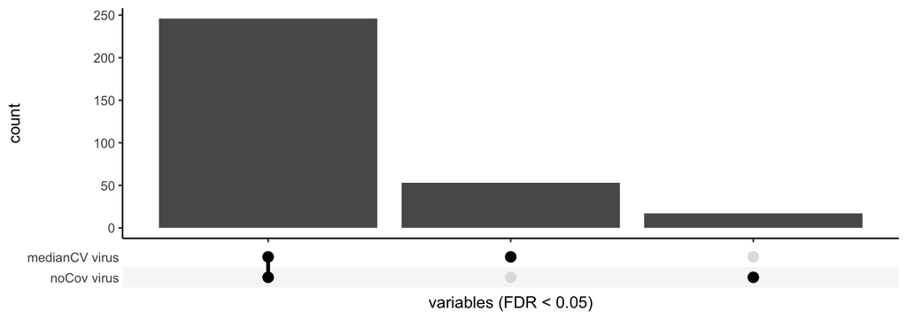

```r
plot_upset_genes(model_result = list("noCov"=example.model,
                                    "medianCV"=example.model2),
                models = "lme",
                variables = "virus",
                fdr_cutoff = 0.05)
```

### `plot_genes`: Expression and model result summary for 1 gene

A single wrapper function to get a table of model result and boxplots associated with model variables for one gene at a time.

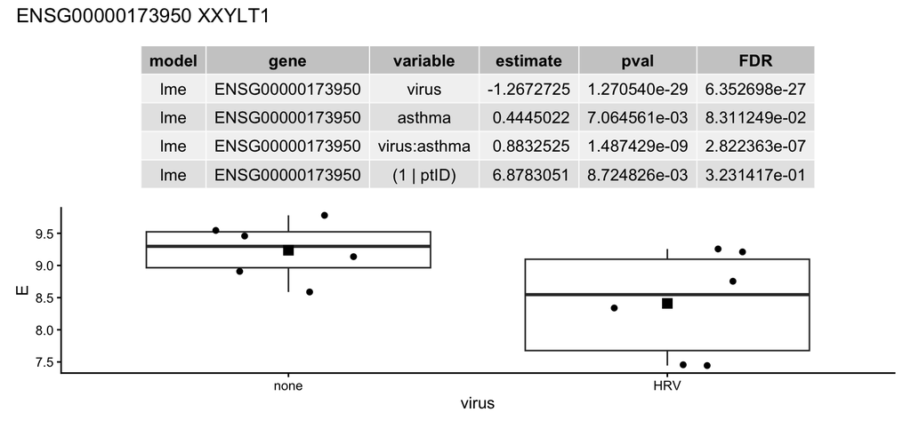

```r
plot_genes(dat = example.voom,
           fdr = example.model$lme,
           subset_genes = "ENSG00000173950",
           variables = "virus")
```

Plot multiple variables including interaction terms, which also add the main model terms associated with the interaction (e.g. if A:B, also plots A and B)

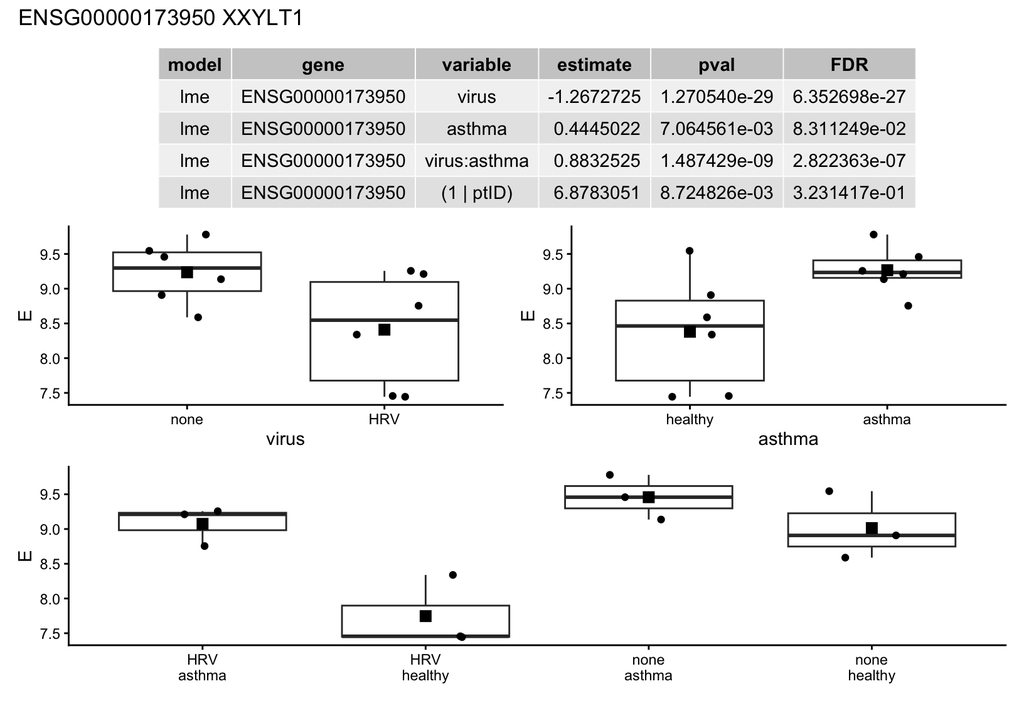

```r
plot_genes(dat = example.voom,
           fdr = example.model$lme,
           subset_genes = "ENSG00000173950",
           variables = "virus:asthma")
```

Color boxplots by a variable of interest. This can be a variable already being plotted or a new variable.

[figure not shown]

```r
plot_genes(dat = example.voom,
           fdr = example.model$lme,
           subset_genes = "ENSG00000173950",
           variables = c("virus","asthma"),
           colorID = "virus")
```

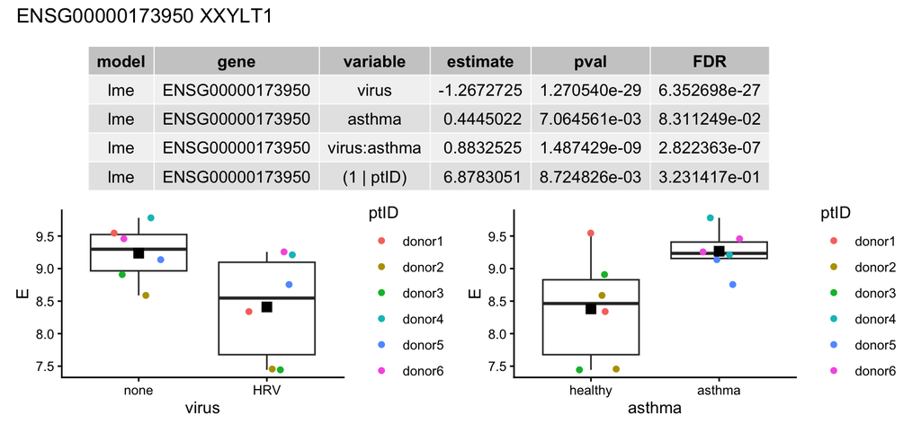

```r
plot_genes(dat = example.voom,
           fdr = example.model$lme,
           subset_genes = "ENSG00000173950",
           variables = c("virus","asthma"),
           colorID = "ptID")
```

Plot many genes quickly using multiple processors. Not run in this document to save space.

```r
deg <- example.model$lme %>% filter(FDR<0.001) %>% pull(gene)
length(deg)

plot.ls <- plot_genes(dat = example.voom,
                      fdr = example.model$lme,
                      subset_genes = deg,
                      variables = "virus",
                      processors = 6)

#Save each plot
#Change settings as needed
outdir <- "~/Desktop/"
fig.width <- 8
fig.height <- 5

for(gene in names(plot.ls)){
  f <- paste0(outdir, gene, ".png")
  ggsave(filename = f, plot = plot.ls[[gene]],
         width = fig.width, height = fig.height)
}
```

Other parameters

- You can also provide expression data not in a `edgeR` or `voom` object with `counts`, `meta`, and optionally `genes`
- If your data have different variable names, use `libraryID` and `geneID` to change them

# Gene set enrichment

## Hypergeometric / pathway enrichment / Fisher’s exact test

These functions use the outputs from `SEARchways::BIGprofiler` and `SEARchways::flexEnrich`.

### `plot_enrich2`: Lollipop plot

The default plot for `plot_enrich2` is what we call a lollipop plot, and it only shows results with FDR < 0.2.

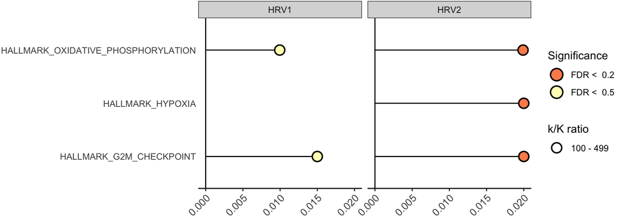

```r
plot_enrich2(df = enrich)
```

### `plot_enrich2`: Dotplot

Change the `chart_style` to a dotplot

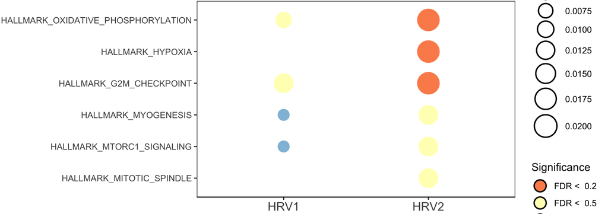

```r
plot_enrich2(df = enrich,
             fdr_cutoff = 0.3,
             chart_style = "dot")
```

Use an outline to denote results below an FDR cutoff. Note this only applies to dotplots.

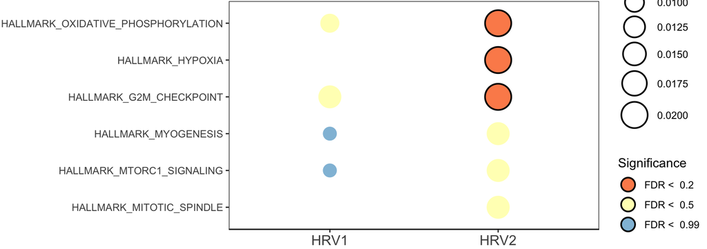

```r
plot_enrich2(df = enrich,
             fdr_cutoff = 0.3,
             chart_style = "dot",
             dot_sig_cutoff = 0.2)
```

### `plot_enrich2`: Barplot

Change the `chart_style` to a barplot.

Note that barplots can only be created with a single group of enrichment results.

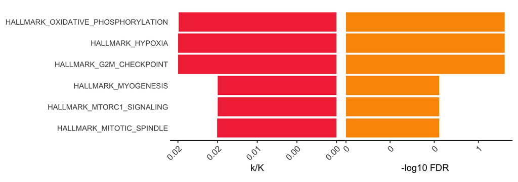

```r
plot_enrich2(df = enrich %>%
               dplyr::filter(group=="HRV2"),
             fdr_cutoff = 0.3,
             chart_style = "bar")
```

### `plot_enrich2`: Shared parameters

You can change the FDR cutoff and/or FDR colors groups.

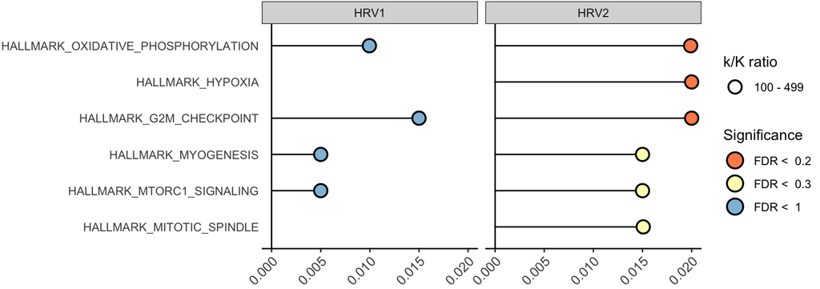

```r
plot_enrich2(df = enrich,
             fdr_cutoff = 0.3,
             fdr_binned_colors = c(0.2, 0.3, 1))
```

For set the FDR coloring to a log color gradient.

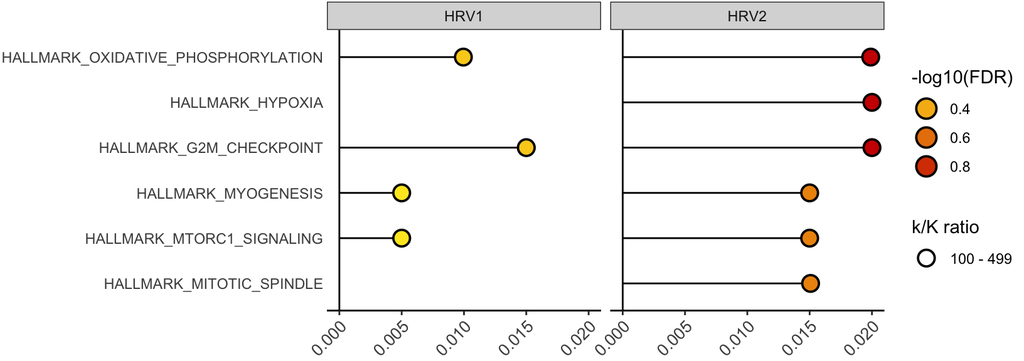

```r
plot_enrich2(df = enrich,
             fdr_cutoff = 0.3,
             fdr_continuous = TRUE)
```

Order the gene sets / pathways. By default, they are ordered by fdr. You can also order by “hclust” of gene membership, “overlap_size”, “gs_size”, “ratio”, “fdr”, or “input”.

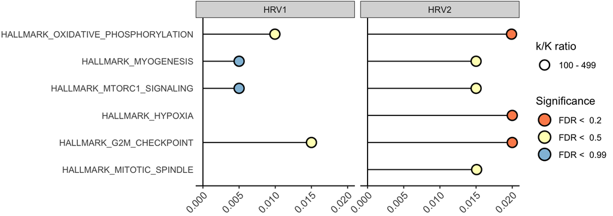

```r
plot_enrich2(df = enrich,
             fdr_cutoff = 0.3,
             y_grouping_method = "gs_size")
```

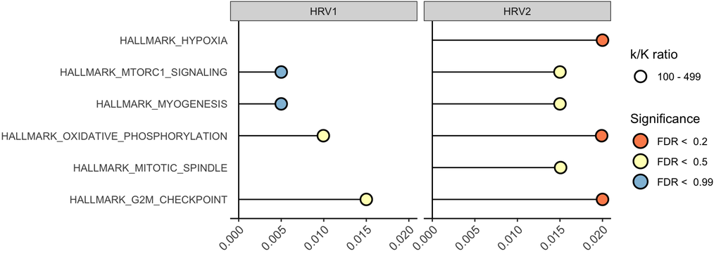

```r
plot_enrich2(df = enrich,
             fdr_cutoff = 0.3,
             y_grouping_method = "hclust")
```

```r
#etc...
```

Add total gene set sizes.

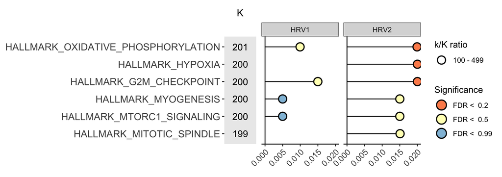

```r
plot_enrich2(df = enrich,
             fdr_cutoff = 0.3,
             include_gssize = TRUE)
```

Other parameters

- Change the data column names to match your data if you are not using `SEARchways` results with `_col` parameters (`pathway_col`, `gene_col`, `ratio_col`, `fdr_col`, `gssize_col`, `dot_groupcol`)
  - These parameters can also be used to change which variable is mapped to which plot aesthetic.

### `plot_enrichgrid`: Add gene level info to `plot_enrich2` plot

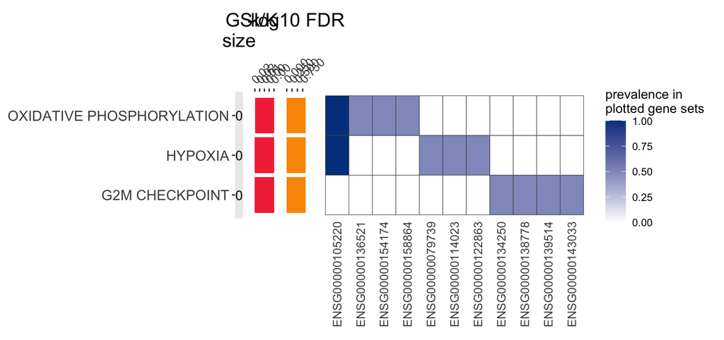

```r
#Modify pathway names for a prettier plot
enrich <- enrich %>%
  mutate(pathway = gsub("HALLMARK_","",pathway),
         pathway = gsub("_","\n",pathway))

plot_enrichgrid(df = enrich,
                df_group = "HRV2")
```

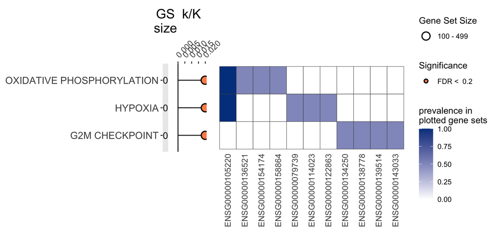

```r
plot_enrichgrid(df = enrich,
                df_group = "HRV2",
                chart_style = "lollipop")
```

Order genes in the heatmap including “hclust”, “prevalence”, “input”, “alphabetical”, or “geneset”.

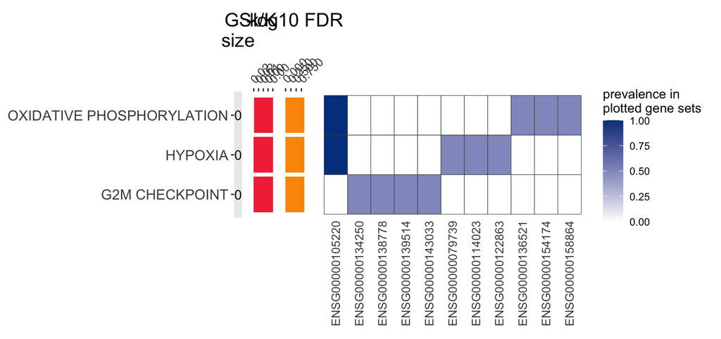

```r
plot_enrichgrid(df = enrich,
                df_group = "HRV2",
                x_grouping_method = "prevalence")
```

Color genes by a binary prevalence cutoff instead of a heatmap.

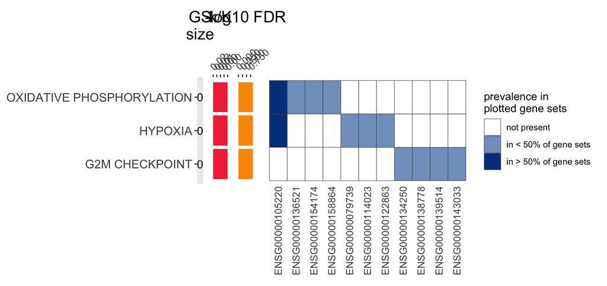

```r
plot_enrichgrid(df = enrich,
                df_group = "HRV2",
                prevalence_color = "cutoff",
                prevalence_cutoff = 0.5)
```

Only plot specific genes of interest.

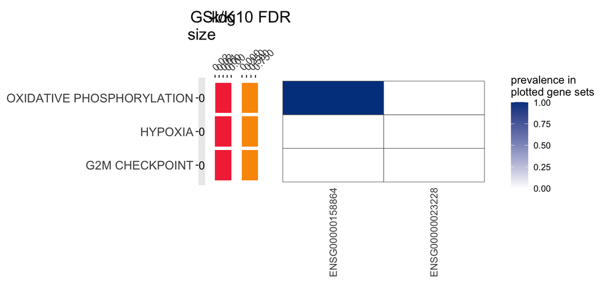

```r
plot_enrichgrid(df = enrich,
                df_group = "HRV2",
                custom_genelist = c("ENSG00000023228", "ENSG00000158864"))
```

Quickly get the equivalent plot without the gene grid without having to convert to `plot_enrich2`.

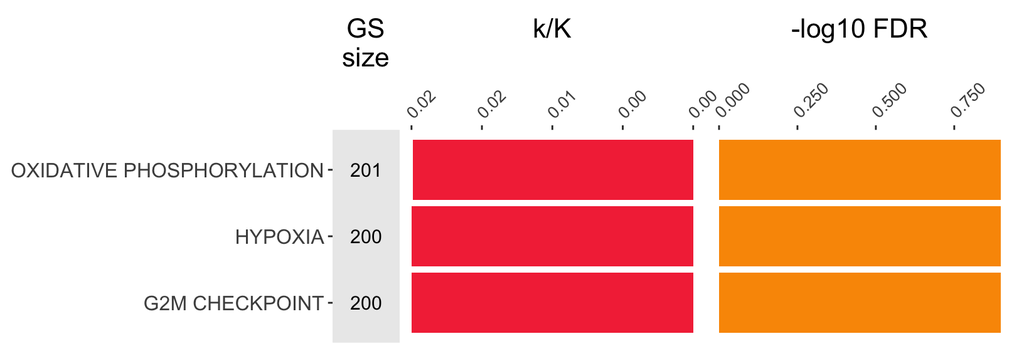

```r
plot_enrichgrid(df = enrich,
                df_group = "HRV2",
                include_grid = FALSE)
```

Other parameters

- See `plot_enrich2` Shared parameters for info on `fdr_cutoff`, `fdr_binned_colors`, `y_grouping_method`, `pathway_col`, `gene_col`, `ratio_col`, `fdr_col`, `gssize_col`
- Note that `chart_style` only supports “bar” or “lollipop” for this function

## GSEA: Gene set enrichment analysis

### `plot_gsea`: Lollipop plot

Plot a lollipop plot of GSEA normalized enrichment scores (NES). Will be superseded by `plot_fit2`.

Here, we use a ridiculous FDR cutoff, because there are actually no significant results in the example data.

```r
plot_gsea(gsea = gsea,
          fdr_cutoff = 0.8, fdr_colors = c(0.5))
```

[output not shown]

# STRING network

Get some genes of interest. These can be ENSEMBL or HGNC. Here, we pull some genes from gene sets in MSigDB, but you may wish to plot DEGs, GSEA leading edge, etc.

```r
db <- msigdbr::msigdbr(species = "Homo sapiens", collection = "H")
genes <- db %>%
  filter(gs_name %in% c("HALLMARK_OXIDATIVE_PHOSPHORYLATION",
                        "HALLMARK_HYPOXIA"))%>%
  pull(ensembl_gene) %>% unique()
genes <- genes[c(1:20,250:270)]
#Add some results from enrichment so plot is more interesting
genes <- unique(c(genes, "ENSG00000079739", "ENSG00000105220", "ENSG00000114023",
           "ENSG00000122863", "ENSG00000136521", "ENSG00000154174",
           "ENSG00000158864", "ENSG00000023228"))
```

## `map_string`: Map genes to STRING database

Map genes of interest to the STRING network database. You can update the STRING version as needed. By default, connections are retained with combined score > 400 (e.g. medium confidence).

```r
map <- map_string(genes, version = 12.0)
names(map)
```

```
## [1] "map"      "subgraph"
```

```r
head(map$map)
```

```
##              gene            STRING_id
## 1 ENSG00000144476 9606.ENSP00000272928
## 2 ENSG00000148926 9606.ENSP00000436607
## 3 ENSG00000170425 9606.ENSP00000304501
## 4 ENSG00000162433 9606.ENSP00000378743
## 5 ENSG00000131016 9606.ENSP00000384537
## 6 ENSG00000149925 9606.ENSP00000496166
```

Change the combined scored threshold. For example, to “strong” confidence connections.

```r
map <- map_string(genes, version = 12.0,
                  score_threshold = 700)
```

Other parameters

- You can switch to mouse data with `species = 'mouse'`

## `plot_string`: Plot a STRING map

Now you can plot the STRING network map.

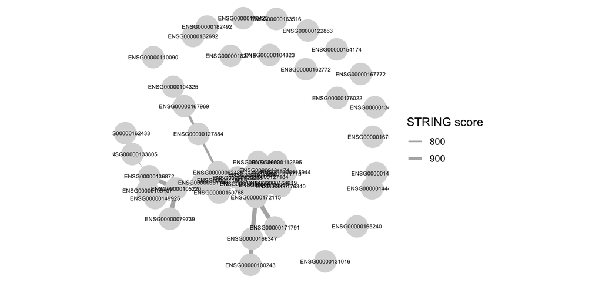

```r
plot_string(map = map)
```

Control the layout if you don’t like the automatically chosen one. See options in `igraph::layout_with_`

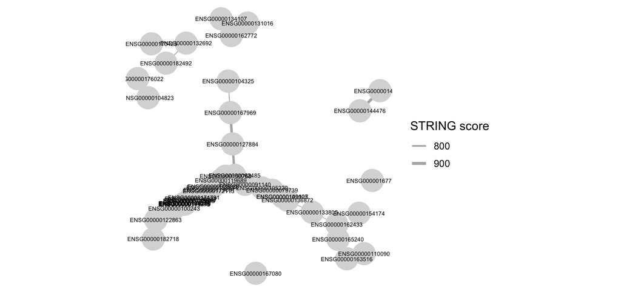

```r
plot_string(map = map,
            layout = "mds")
```

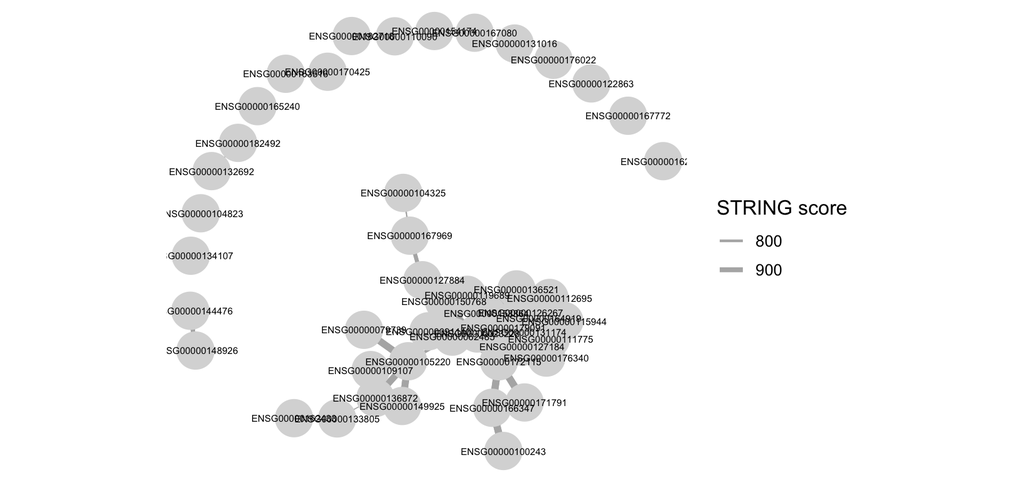

```r
plot_string(map = map,
            layout = "kk")
```

Remove orphans (nodes with no edge connections).

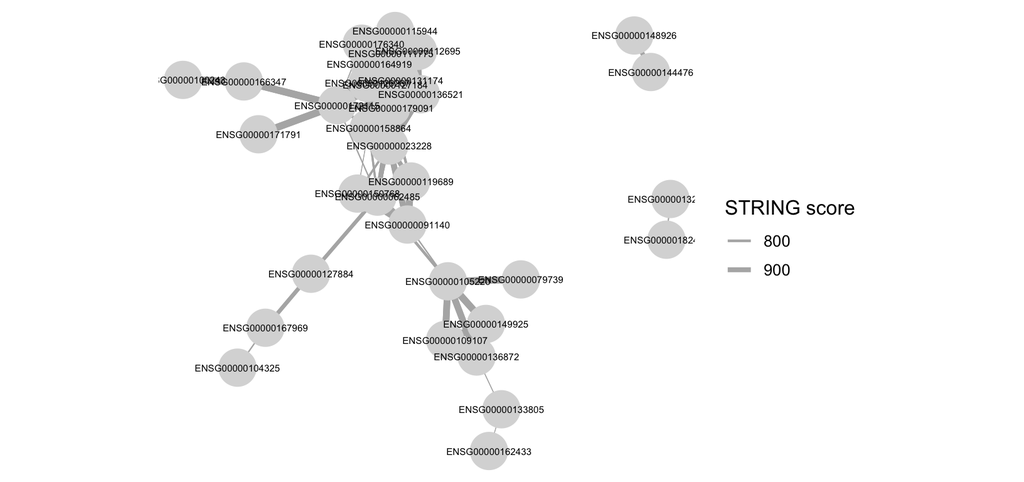

```r
plot_string(map = map,
            edge_min = 1)
```

Plot just orphans (nodes with no edge connections).

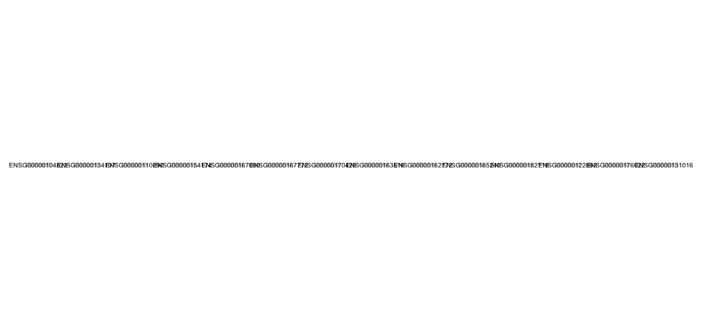

```r
plot_string(map = map,
            edge_max = 0)
```

Plot just the largest cluster. The large “lgl” layout is usually best for these.

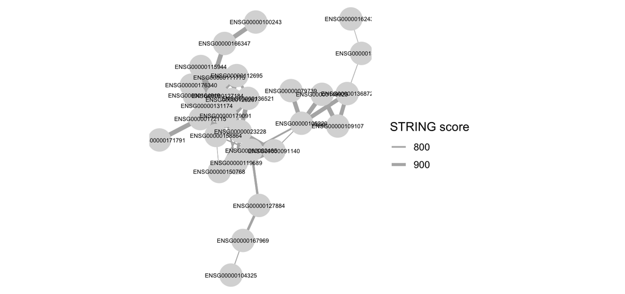

```r
plot_string(map = map, layout = "lgl",
            main_cluster_only = TRUE)
```

Map enrichment or GSEA results from `SEARchways` to your network.

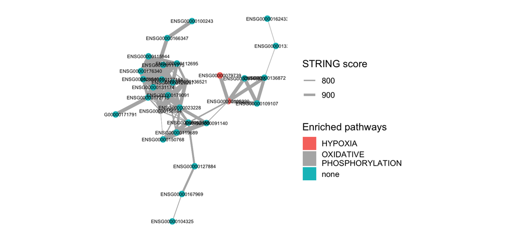

```r
enrich.select <- enrich %>%
  filter(group=="HRV2")

plot_string(map = map, layout = "lgl",
            main_cluster_only = TRUE,
            enrichment = enrich.select)
```

Change the cutoffs of what enrichment results are included.

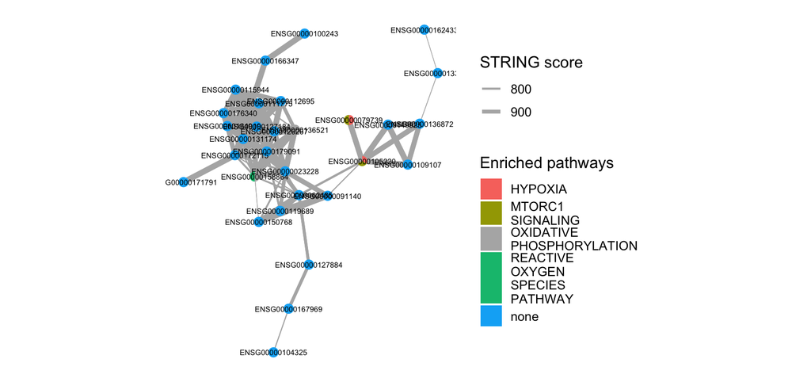

```r
plot_string(map = map, layout = "lgl",
            main_cluster_only = TRUE,
            enrichment = enrich.select,
            overlap = 1, fdr_cutoff = 0.5)
```

Only included genes in selected (by cutoffs) enrichment pathways.

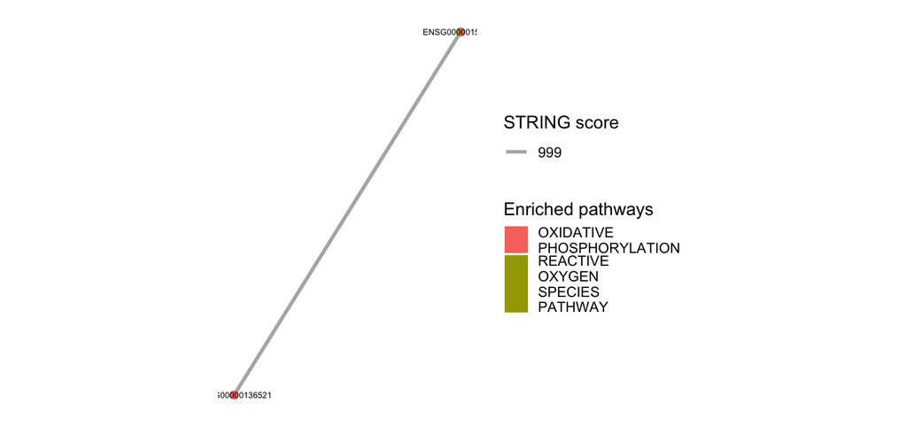

```r
plot_string(map = map, layout = "lgl",
            main_cluster_only = TRUE,
            enrichment = enrich.select,
            overlap = 1, fdr_cutoff = 0.5,
            enriched_only = TRUE)
```

Change the aesthetics of the plot.

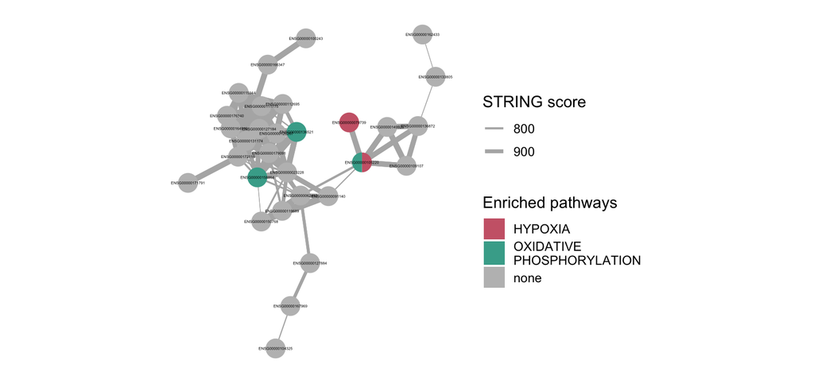

```r
plot_string(map = map, layout = "lgl",
            main_cluster_only = TRUE,
            enrichment = enrich.select,
            text_size = 1,
            node_size = 2,
            colors = c("#CC6677", "#44AA99", "grey"))
```

# Heatmap

## `get_hm_clust`: Extract genes in `ComplexHeatmap` clusters

Create a heatmap to apply the function to.

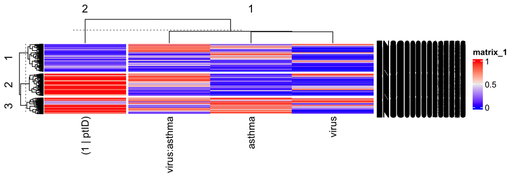

```r
library(ComplexHeatmap)
hm.dat <- example.model$lme %>%
          select(gene, variable, pval) %>%
          pivot_wider(names_from = variable, values_from = pval) %>%
          column_to_rownames("gene") %>% as.matrix()

# The km determine cutoffs for clusters
example.hm <- Heatmap(hm.dat, row_km=3, column_km=2)
example.hm <- draw(example.hm)
```

Extract row (gene usually) clusters.

```r
get_hm_clust(dat = hm.dat,
             hm = example.hm, dimension = "row") %>%
  head()
```

```
##                 row row_within_cluster  cluster
## 581 ENSG00000115568                  1 cluster1
## 582 ENSG00000111642                  2 cluster1
## 583 ENSG00000061794                  3 cluster1
## 584 ENSG00000120875                  4 cluster1
## 585 ENSG00000167325                  5 cluster1
## 586 ENSG00000164300                  6 cluster1
```

Extract column (variable or sample usually) clusters.

```r
get_hm_clust(dat = hm.dat,
             hm = example.hm, dimension = "col")
```

```
##            col col_within_cluster  cluster
## 4   (1 | ptID)                  1 cluster1
## 1 virus:asthma                  1 cluster2
## 2       asthma                  2 cluster2
## 3        virus                  3 cluster2
```

# Superceded functions

## `plot_enrich`: Lollipop plot

There is also the older `plot_enrich` that only supports lollipop plots and will be deprecated once `plot_enrich2` can handle GSEA results.

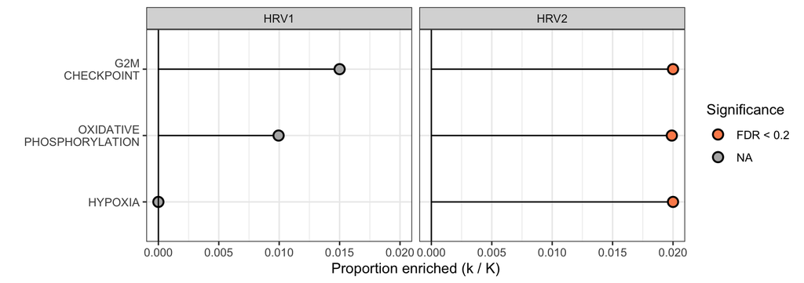

```r
plot_enrich(enrich = enrich)
```

## `plot_fit`: Compare fit metrics

There is also the original `plot_fit`, which has a subset of the `plot_fit2` parameters. Each point is a gene colored by the best fit model (delta AIC > or < 0). This plot is less preferred as it is difficult to see small changes in AIC and many genes overlap.

```
## Summary
```

```
##                                      Best fit Metric Total genes Mean delta
## 1    lme_virus_asthma_virus:asthma_(1 | ptID)    AIC         273  0.3958556
## 2 lmerel_virus_asthma_virus:asthma_(1 | ptID)    AIC         466  0.2983838
## 3                                        none    AIC         261  0.0000000
##   Stdev delta
## 1   0.4044870
## 2   0.2582185
## 3   0.0000000
```

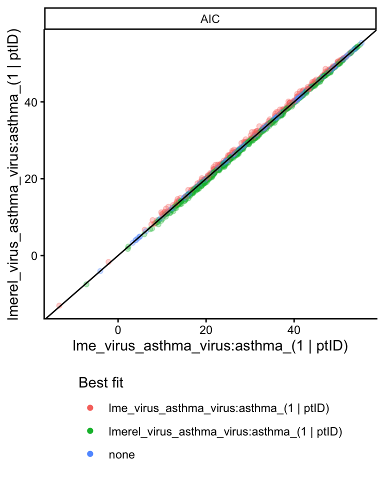

```r
plot_fit(model_result = example.model, x="lme",
         model_result_y = example.model, y="lmerel")
```